# re_linear_regression

FB

2025-04-08

```r
library(ggplot2)
library(dplyr)
library(ggcorrplot)
library(here)
```

# Chapter 9 - Linear Regression

## 1. Load data and prepare for analysis

```r
half_hourly_fluxes <- readr::read_csv(here("data","half_hourly_fluxes.csv"))
#little summary of the missing values
colSums(is.na(half_hourly_fluxes))
```

```
##         siteid      TIMESTAMP           TA_F        SW_IN_F        LW_IN_F
##              0              0              0              0              0
##          VPD_F           PA_F            P_F           WS_F       TA_F_MDS
##              0              0              0              0            325
##    SW_IN_F_MDS    LW_IN_F_MDS      VPD_F_MDS      CO2_F_MDS        PPFD_IN
##            341          11057            768            290           4574
## GPP_NT_VUT_REF          USTAR
##           2426           2468
```

```r
#drop rows with nan in response variables
response_variable <- half_hourly_fluxes[!is.na(half_hourly_fluxes$GPP_NT_VUT_REF), ]

#create vector
subset <- c("GPP_NT_VUT_REF", "TA_F", "SW_IN_F", "LW_IN_F", "VPD_F", "PA_F", "P_F",
  "WS_F", "CO2_F_MDS", "PPFD_IN", "USTAR")

cleaned_data <- response_variable[, subset]

cleaned_data <- cleaned_data[complete.cases(cleaned_data),]
```

## 2. Analysis

### 2.1 intercept-only

#### 2.1.1 Calculation

```r
model_1 <- lm(formula = GPP_NT_VUT_REF ~ 1, data = cleaned_data)

aic <- AIC(model_1)
```

#### 2.1.2 Visualization

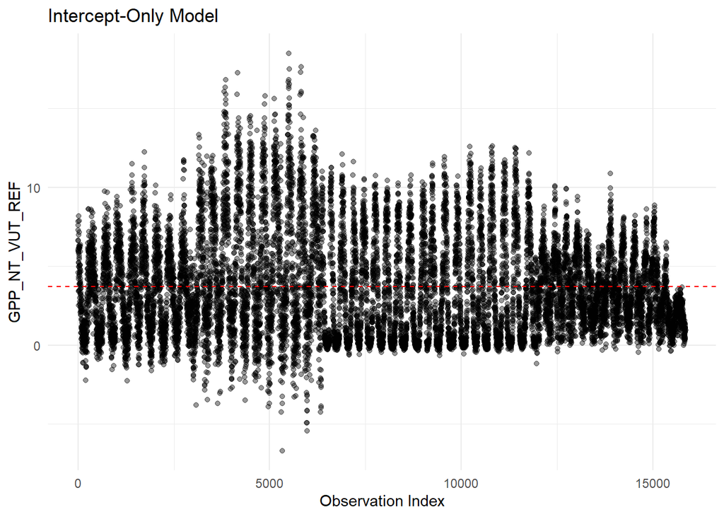

Figure 1: Intercept-only Linear Regression

```r
ggplot(cleaned_data, aes(x = 1:nrow(cleaned_data), y = GPP_NT_VUT_REF)) +
  geom_point(alpha = 0.4) +
  geom_hline(yintercept = coef(model_1)[1], color = "red", linetype = "dashed") +
  labs(title = "Intercept-Only Model",
       x = "Observation Index",
       y = "GPP_NT_VUT_REF") +
  theme_minimal()
```

This model shows us the GPP_NT_VUT_REF across the observation indices, which corresponds to time-ordered measurements. The red dashed line gives us the mean of all GPP_NT_VUT_REF values.

### 2.2 Setting up the model and add one Predictor; Step 1-3

#### 2.2.1 setting up the model; step 1-3

```r
predictors <- c("TA_F", "SW_IN_F", "LW_IN_F", "VPD_F", "PA_F", "P_F",
  "WS_F", "CO2_F_MDS", "PPFD_IN", "USTAR")

best_aic <- aic
best_predictor <- NULL
aic_results <- data.frame(predictor = character (), aic = numeric())

for (pred in predictors) {
  formula <- as.formula(paste("GPP_NT_VUT_REF ~", pred))
  model_2 <- lm(formula, data = cleaned_data)

  #print aic
  aic_2 <- AIC(model_2)
  cat("Predictor:", pred, "| AIC:", aic_2, "\n")

  aic_results <- rbind(aic_results, data.frame(predictor = pred, aic = aic_2))

  #if aic is better then before
  if (aic_2 < best_aic) {
    best_aic <- aic_2
    best_predictor <- pred
  }
}
```

```
## Predictor: TA_F | AIC: 75081.29
## Predictor: SW_IN_F | AIC: 73689.31
## Predictor: LW_IN_F | AIC: 80148.59
## Predictor: VPD_F | AIC: 79203
## Predictor: PA_F | AIC: 82496.49
## Predictor: P_F | AIC: 82454.03
## Predictor: WS_F | AIC: 82173.43
## Predictor: CO2_F_MDS | AIC: 81859.9
## Predictor: PPFD_IN | AIC: 73389.05
## Predictor: USTAR | AIC: 82462.99
```

```r
cat("\n Best predictor in step 1 is:", best_predictor, "| AIC:", best_aic, "\n")
```

```
##
##  Best predictor in step 1 is: PPFD_IN | AIC: 73389.05
```

#### 2.2.2 Visualization

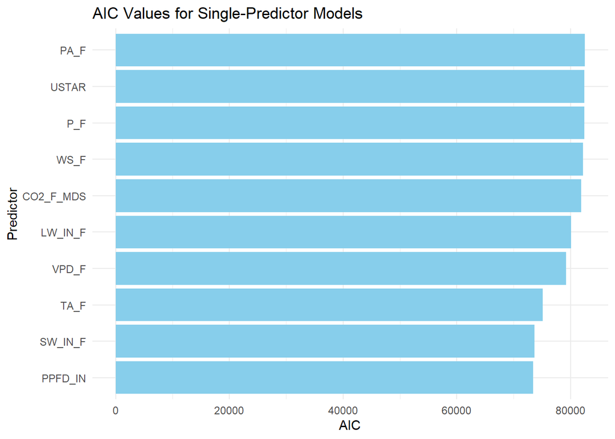

Figure 2: AIC Values for Predictors

```r
ggplot(aic_results, aes(x = reorder(predictor, aic), y = aic)) +
  geom_col(fill = "skyblue") +
  coord_flip() +
  labs(title = "AIC Values for Single-Predictor Models",
       x = "Predictor",
       y = "AIC") +
  theme_minimal()
```

In the initial step of the model selection, PPFD_IN was chosen as the first predictor. This variable also shows the strongest correlation with GPP_NT_VUT_REF as seen in 2.3.4. PPFD_IN represents the Photosynthetic photon flux density (incoming). This is a measure of how much light is available for photosynthesis. Given that photosynthesis is fundamentally driven by light, the strong predictive power of PPFD_IN in explaining GPP best out of all the variables is ecologically justified.

### 2.3 Full implementation stepwise forward regression

#### 2.3.1 Code

```r
predictors_2 <- c("TA_F", "SW_IN_F", "LW_IN_F", "VPD_F", "PA_F", "P_F",
                  "WS_F", "CO2_F_MDS", "USTAR")
selected_predictors <- c("PPFD_IN")

aic_progress <- data.frame(step = integer(), predictor = character(), aic = numeric())


improvement <- TRUE

while (improvement) {
  best_aic_2 <- best_aic
  best_predictor <- NULL

  for (pre in predictors_2) {
    formula <- as.formula(paste("GPP_NT_VUT_REF ~",
                                paste(c(selected_predictors, pre), collapse = " + ")))

    model_3 <- lm(formula, data = cleaned_data)
    aic_3 <- AIC(model_3)
    cat("Predictor:", pre, "| AIC:", aic_3, "\n")

    if (aic_3 < best_aic_2) {
      best_aic_2 <- aic_3
      best_predictor <- pre
      best_model <- model_3
    }
  }

  if (!is.null(best_predictor)) {
    selected_predictors <- c(selected_predictors, best_predictor)
    predictors_2 <- setdiff(predictors_2, best_predictor)
    best_aic <- best_aic_2
    current_model <- best_model
    cat("added:", best_predictor, "| new best AIC:", best_aic, "\n\n")
    aic_progress <- rbind(aic_progress, data.frame(
    step = length(selected_predictors),
    predictor = best_predictor,
    aic = best_aic
))

  } else {
    improvement <- FALSE
    cat("No more improvement. Final model.\n")
  }
}
```

```
## Predictor: TA_F | AIC: 71744.5
## Predictor: SW_IN_F | AIC: 73391.03
## Predictor: LW_IN_F | AIC: 70814.23
## Predictor: VPD_F | AIC: 72900.92
## Predictor: PA_F | AIC: 73334.03
## Predictor: P_F | AIC: 73182.84
## Predictor: WS_F | AIC: 73346.74
## Predictor: CO2_F_MDS | AIC: 73352.57
## Predictor: USTAR | AIC: 73384.17
## added: LW_IN_F | new best AIC: 70814.23
##
## Predictor: TA_F | AIC: 70816.09
## Predictor: SW_IN_F | AIC: 70803.29
## Predictor: VPD_F | AIC: 69288.87
## Predictor: PA_F | AIC: 70744.51
## Predictor: P_F | AIC: 70811.11
## Predictor: WS_F | AIC: 70655.16
## Predictor: CO2_F_MDS | AIC: 70746.2
## Predictor: USTAR | AIC: 70779.35
## added: VPD_F | new best AIC: 69288.87
##
## Predictor: TA_F | AIC: 68682.35
## Predictor: SW_IN_F | AIC: 69117.56
## Predictor: PA_F | AIC: 69286.39
## Predictor: P_F | AIC: 69196.85
## Predictor: WS_F | AIC: 69169.5
## Predictor: CO2_F_MDS | AIC: 69156.66
## Predictor: USTAR | AIC: 69250.25
## added: TA_F | new best AIC: 68682.35
##
## Predictor: SW_IN_F | AIC: 68536.14
## Predictor: PA_F | AIC: 68683.51
## Predictor: P_F | AIC: 68573.42
## Predictor: WS_F | AIC: 68611.04
## Predictor: CO2_F_MDS | AIC: 68609.5
## Predictor: USTAR | AIC: 68671.77
## added: SW_IN_F | new best AIC: 68536.14
##
## Predictor: PA_F | AIC: 68538.05
## Predictor: P_F | AIC: 68434.9
```

[output cut: 9 more lines]

```
## added: WS_F | new best AIC: 68359.48
##
## Predictor: PA_F | AIC: 68359.06
## Predictor: CO2_F_MDS | AIC: 68301.86
## Predictor: USTAR | AIC: 68287.91
## added: USTAR | new best AIC: 68287.91
##
## Predictor: PA_F | AIC: 68263.6
## Predictor: CO2_F_MDS | AIC: 68203.85
## added: CO2_F_MDS | new best AIC: 68203.85
##
## Predictor: PA_F | AIC: 68175.45
## added: PA_F | new best AIC: 68175.45
##
## No more improvement. Final model.
```

#### 2.3.2 Visualization

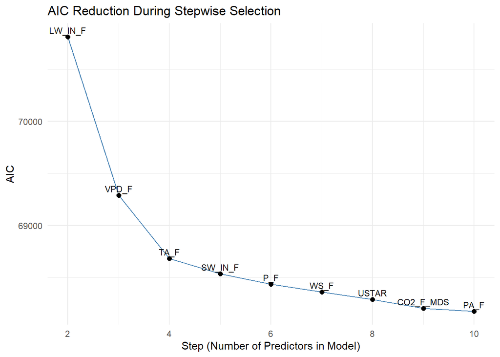

Figure 3: AIC Reduction

```r
ggplot(aic_progress, aes(x = step, y = aic, label = predictor)) +
  geom_line(color = "steelblue") +
  geom_point(size = 2) +
  geom_text(vjust = -0.5, size = 3) +
  labs(title = "AIC Reduction During Stepwise Selection",
       x = "Step (Number of Predictors in Model)",
       y = "AIC") +
  theme_minimal()
```

As seen in Figure 3, the largest reduction of the AIC is in the 1-4th steps. Later variables improved the AIC only sightly.

Redundancy between predictor variables can influence the order in which they are selected or lead to an exclusion of some variables. . For instance, although SW_INF is strongly correlated with the response variables (see 2.3.4), it was added later on in the process (step 5). This may be due to the extremely high correlation with PPFD_IN, which was selected in the first step. Likely, PPFD_IN already captures a significant amount of the variance which SW_IN_F could explain.

#### 2.3.3 Summary Statistics

```r
summary(current_model)
```

```
##
## Call:
## lm(formula = formula, data = cleaned_data)
##
## Residuals:
##     Min      1Q  Median      3Q     Max
## -7.7668 -1.2386 -0.0999  1.1247 12.2020
##
## Coefficients:
##               Estimate Std. Error t value Pr(>|t|)
## (Intercept) -2.2403366  0.4665182  -4.802 1.58e-06 ***
## PPFD_IN      0.0059811  0.0005308  11.269  < 2e-16 ***
## LW_IN_F      0.0150051  0.0007218  20.788  < 2e-16 ***
## VPD_F       -0.4054610  0.0082214 -49.318  < 2e-16 ***
## TA_F         0.1199348  0.0054172  22.140  < 2e-16 ***
## SW_IN_F      0.0136685  0.0011036  12.386  < 2e-16 ***
## P_F         -0.0263734  0.0030970  -8.516  < 2e-16 ***
## WS_F        -0.4200943  0.0287743 -14.600  < 2e-16 ***
## USTAR        1.9196775  0.1690389  11.356  < 2e-16 ***
## CO2_F_MDS   -0.0076067  0.0008003  -9.505  < 2e-16 ***
## PA_F         0.0198534  0.0036000   5.515 3.54e-08 ***
## ---
## Signif. codes:  0 '***' 0.001 '**' 0.01 '*' 0.05 '.' 0.1 ' ' 1
##
## Residual standard error: 2.076 on 15845 degrees of freedom
## Multiple R-squared:  0.5952, Adjusted R-squared:  0.5949
## F-statistic:  2330 on 10 and 15845 DF,  p-value: < 2.2e-16
```

```r
print(selected_predictors)
```

```
##  [1] "PPFD_IN"   "LW_IN_F"   "VPD_F"     "TA_F"      "SW_IN_F"   "P_F"
##  [7] "WS_F"      "USTAR"     "CO2_F_MDS" "PA_F"
```

The model explains ~59.5% of the variance in GPP_NT_VUT_REF.

#### 2.3.4 Correlation between Predictors

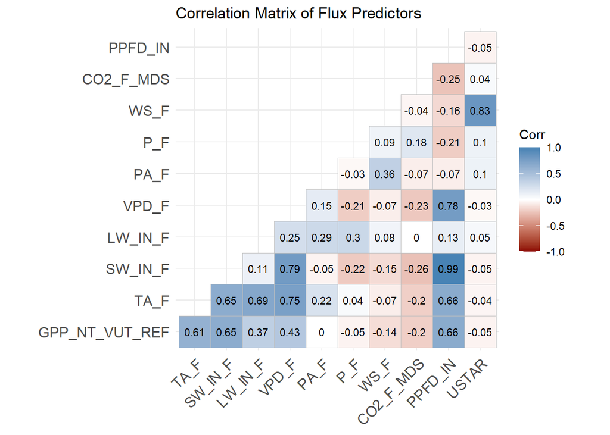

Figure 4: Correlation Matrix

```r
corr_matrix <- cor(cleaned_data, use = "complete.obs")

# Plot the correlation matrix
ggcorrplot(corr_matrix,
           method = "square",
           type = "lower",
           lab = TRUE,
           lab_size = 3,
           colors = c("darkred", "white", "steelblue"),
           title = "Correlation Matrix of Flux Predictors",
           ggtheme = theme_minimal())
```